```python
import helpers
```

# Loading Data

```python
hourly = helpers.parse_raw_data('data/hour.csv')
daily = helpers.parse_raw_data('data/day.csv')

hourly.describe().T[["min", "mean", "max", "std", "count"]]
```

|  | min | mean | max | std | count |
| --- | --- | --- | --- | --- | --- |
| date | 2011-01-01 00:00:00 | 2012-01-02 04:08:34.552045 | 2012-12-31 00:00:00 | NaN | 17379 |
| year | 0.0 | 0.502561 | 1.0 | 0.500008 | 17379.0 |
| month | 1.0 | 6.537775 | 12.0 | 3.438776 | 17379.0 |
| hour | 0.0 | 11.546752 | 23.0 | 6.914405 | 17379.0 |
| holiday | 0.0 | 0.02877 | 1.0 | 0.167165 | 17379.0 |
| weekday | 0.0 | 3.003683 | 6.0 | 2.005771 | 17379.0 |
| workingday | 0.0 | 0.682721 | 1.0 | 0.465431 | 17379.0 |
| temp | 0.02 | 0.496987 | 1.0 | 0.192556 | 17379.0 |
| atemp | 0.0 | 0.475775 | 1.0 | 0.17185 | 17379.0 |
| hum | 0.0 | 0.627229 | 1.0 | 0.19293 | 17379.0 |
| windspeed | 0.0 | 0.190098 | 0.8507 | 0.12234 | 17379.0 |
| casual | 0.0 | 35.676218 | 367.0 | 49.30503 | 17379.0 |
| registered | 0.0 | 153.786869 | 886.0 | 151.357286 | 17379.0 |
| total | 1.0 | 189.463088 | 977.0 | 181.387599 | 17379.0 |

# How should we define bad weather?

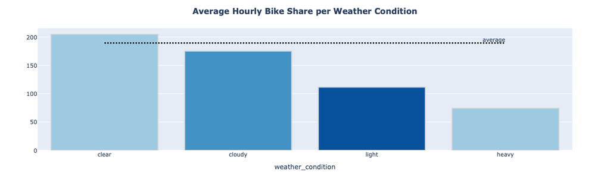

```python
helpers.plot_usage_per_weather_condition(hourly, metric='total')
```

**Interpretation: light and heavy rain significantly decreases demand**

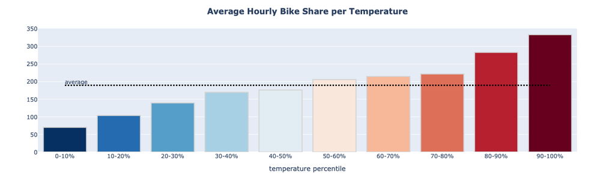

```python
helpers.plot_usage_per_temperature(hourly, metric='total')
```

**Interpretation: extreme cold temperatures (0-20% percentiles) influence demand the most**

For an hour to be considered 'bad weather' it needs to satisfy one of:

1. Light or Heavy falls (rain, snow, hailing); or
2. Extreme cold temperatures (0-20% percentiles)

```python
helpers.table_bad_weather_recap(hourly, metric='total')
```

|  | n_hours | hours_pct | avg_demand_per_hour |
| --- | --- | --- | --- |
| good weather | 12,732 | 73% | 224 |
| bad weather | 4,647 | 27% | 95 |

# Naive effect estimate

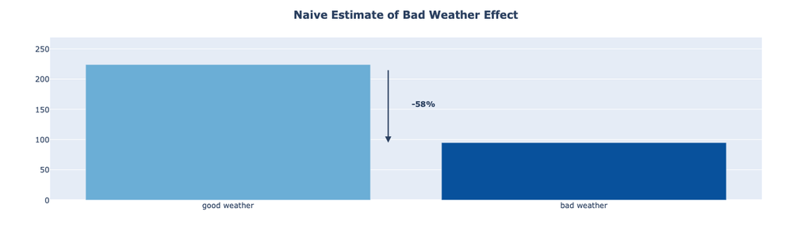

```python
helpers.plot_naive_estimate(hourly, metric='total')
```

**Interpretation: bad weather reduces demand by ~60% (naive estimation)**

- This estimate is biased because weather is not randomly assigned
- We should compare demand under different weather conditions within the same time context (hour, weekday, season)
- That would isolate the causal effect of weather as the naïve method overestimates the effect

# Confounding Factors

## Monthly Seasonality

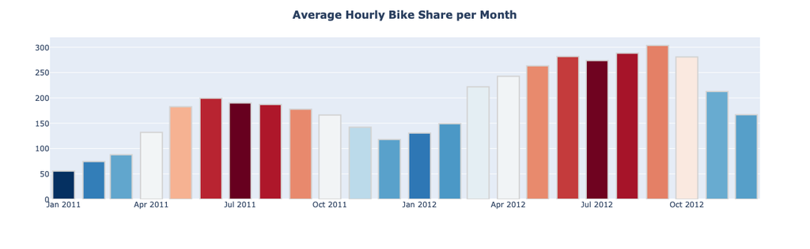

```python
helpers.plot_usage_per_month(hourly, metric='total')
```

**Interpretation 1: winter has lower demand AND colder temperatures (summer the opposite)**

**Interpretation 2: user base is growing over time, we cannot compare fairly the same month in 2011 vs 2012**

*Note: bars are colored based on the average temperature of the month*

## Hour of Day Seasonality

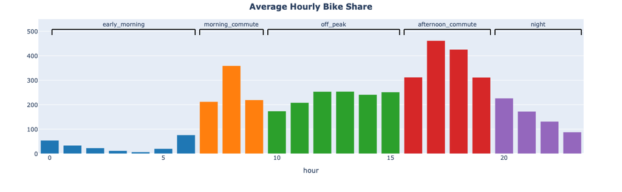

```python
helpers.plot_hourly_usage(hourly, metric='total')
```

**Interpretation: at night, demand is lower AND temperature are generally lower**

# Causal Estimate of Weather Effect

- Method: **regression model with time fixed effects** to control for confounding factors
- Causal Estimate: **the causal effect of bad weather on bike demand is estimated at ~40%** (-39% ± 2% at 95% confidence)
- This compares demand under different weather conditions within the same hour of day, month, and year
- As expected, the naive estimate indeed overestimates the effect

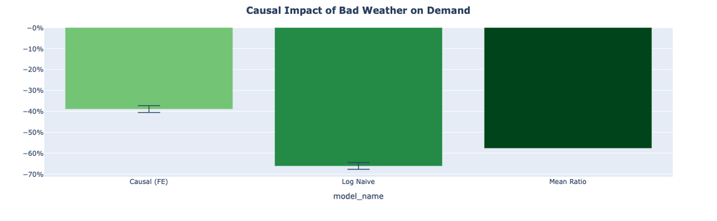

```python
helpers.plot_causal_estimate_against_naive(hourly)
```

# Ensuring the causal model is robust

- The estimated causal effect rapidly converges with model complexity to estimated ~40%
- The effect stabilizes once time confounders are controlled
- We ensured causal model is robust, so we can have high confidence in the final estimate

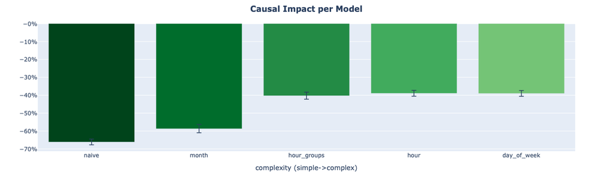

```python
helpers.plot_causal_effect_per_model(hourly)
```

# Segmented Analysis by User Type

- Bad weather reduces demand by ~39% overall
- By user type:
  - casual users: −51% (highly elastic)
  - registered users: −36% (more inelastic)
  - difference: ~15% between casual and registered
- Casual usage is more discretionary while registered usage is more driven by necessity

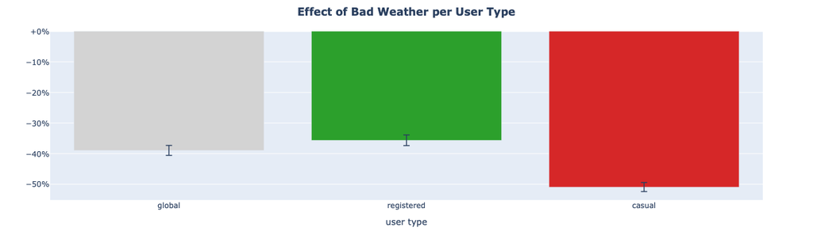

```python
helpers.plot_causal_effect_per_user_type(hourly)
```

# Effect depends on hour of day

**Demand sensitivity varies significantly by time:**

- Most resilient: early morning (−29%)
- Most elastic: off-peak (−46%), afternoon commute (−48%)
- About 20% difference between most resilient and most elastic

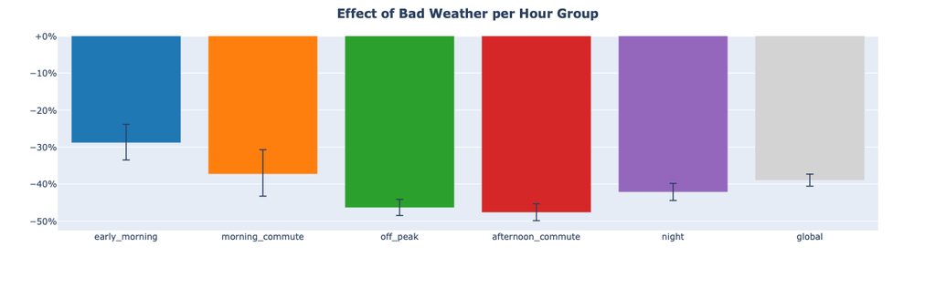

```python
helpers.plot_causal_effect_per_hour_group(hourly)
```

# Limitations

1. Unobserved Demand Shocks (concert, public transport disruptions, ...):
   - Events may affect demand independently of weather
2. Geo-localization:
   - Weather and demand vary accross location
   - Data and model are aggregated and would overlook location-based effects
3. Simplified Weather definition:
   - We defined bad weather as a binary variable, it doesn't capture the intensitiy or coupling effects of weather

# Potential Improvements

- Incorporate external event and transport data
- Use location-level modeling
- Model weather as continuous and add interactions

# Key Takeaways

- **Bad weather reduces demand by ~39% (not 60% as naive method suggested)**
- **Effects are heterogeneous (user type and time of day)**
- **Targeted interventions would outperform uniform policies**